# Polynomial regression

### Linear and polynomial regression with the SALARY dataset

You'll be using different types of regression to predict the salary of employes, based on historical salaries.

**1. Importing modules needed for the work**

```python
import matplotlib.pyplot as plt
import numpy as np
import pandas as pd # data processing, CSV file I/O (e.g. pd.read_csv)
import seaborn as sns
plt.style.use('fivethirtyeight')
import warnings
warnings.filterwarnings('ignore')  #this will ignore the warnings.it wont display warnings in notebook
```

**2. Importing the salary data**

```python
dataset=pd.read_csv('./input/Position_Salaries.csv')
dataset
```

|  | Position | Level | Salary |
| --- | --- | --- | --- |
| 0 | Business Analyst | 1 | 45000 |
| 1 | Junior Consultant | 2 | 50000 |
| 2 | Senior Consultant | 3 | 60000 |
| 3 | Manager | 4 | 80000 |
| 4 | Country Manager | 5 | 110000 |
| 5 | Region Manager | 6 | 150000 |
| 6 | Partner | 7 | 200000 |
| 7 | Senior Partner | 8 | 300000 |
| 8 | C-level | 9 | 500000 |
| 9 | CEO | 10 | 1000000 |

We can see that the dataset has 10 levels and the corresponding salary paid to the employee

#### We only have one usable feature in this dataset

> The features 'Position' and 'Level' are redundant. The **regressor** is the column 'Level'

```python
# extracting the regressor/column/feature 'Level'
X=dataset.iloc[:,1:2].values
X
```

```
array([[ 1],
       [ 2],
       [ 3],
       [ 4],
       [ 5],
       [ 6],
       [ 7],
       [ 8],
       [ 9],
       [10]], dtype=int64)
```

#### We now need to extract the regressand, that is the variable that we eventually want to be able to predict

> the **regressand** is the column 'Salary'

```python
# Extracting the column 'Salary'
y=dataset.iloc[:,2].values
y
```

```
array([  45000,   50000,   60000,   80000,  110000,  150000,  200000,
        300000,  500000, 1000000], dtype=int64)
```

**3. Splitting the data into training and test data**

> Typically at this point we should be splitting the dataset into train and test set. So that we can test out our model after training. However in this simple example we only have few data points. So we´ll be using all of them for training.

> **This is a very bad thing to do!!**

```python
# uncomment the following to create the training and testing datasets
from sklearn.model_selection import train_test_split
X_train,X_test,y_train,y_test=train_test_split(X,y,test_size=0.2,random_state=0)
```

**4. Linear Regression**

```python
from sklearn.linear_model import LinearRegression
lin_reg=LinearRegression()
lin_reg.fit(X,y)
```

```
LinearRegression()
```

**5. Visualizing Linear Regression result**

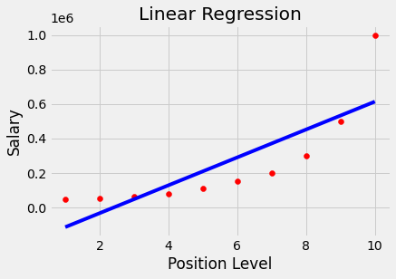

```python
plt.scatter(X,y,color='red')
plt.plot(X,lin_reg.predict(X),color='blue')
plt.title('Linear Regression')
plt.xlabel('Position Level')
plt.ylabel('Salary')
plt.show()
```

**6. Polynomial Regression**  
Since our data is distributed in a non linear way, we'll try fitting it with polynomial curves, to get more accurate models.

```python
# polynomial curve of degree 2
from sklearn.preprocessing import PolynomialFeatures
poly_reg2=PolynomialFeatures(degree=2)
X_poly=poly_reg2.fit_transform(X)
lin_reg_2=LinearRegression()
lin_reg_2.fit(X_poly,y)
```

```
LinearRegression()
```

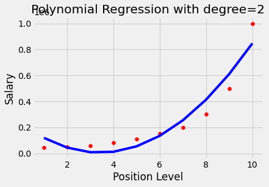

```python
plt.scatter(X,y,color='red')
plt.plot(X,lin_reg_2.predict(poly_reg2.fit_transform(X)),color='blue')
#plt.plot(X,lin_reg_3.predict(poly_reg3.fit_transform(X)),color='green')
plt.title('Polynomial Regression with degree=2')
plt.xlabel('Position Level')
plt.ylabel('Salary')
plt.show()
```

**7. Third-degree Polynomial Regression**  
Since our data is still not fitting very well, we'll try fitting it with a higher-degree polynomial (degree=3), to get more accurate models.

```python
# Polynomial curve of degree 3
poly_reg3=PolynomialFeatures(degree=3)
X_poly3=poly_reg3.fit_transform(X)
lin_reg_3=LinearRegression()
lin_reg_3.fit(X_poly3,y)
```

```
LinearRegression()
```

**8. Visualizing third-degree polynomial**

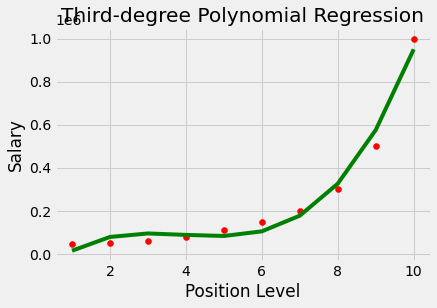

```python
plt.scatter(X,y,color='red')
#plt.plot(X,lin_reg_2.predict(poly_reg2.fit_transform(X)),color='blue')
plt.plot(X,lin_reg_3.predict(poly_reg3.fit_transform(X)),color='green')
plt.title('Third-degree Polynomial Regression')
plt.xlabel('Position Level')
plt.ylabel('Salary')
plt.show()
```

**8. Predicting the salary of an employee with each of the 3 curves** Let´s use the three models to make predictions, to get a feel as to the accuracy we have achieved.

> We now want to predict the salary of an employee comprised into a new level 6.5

```python
lin_reg.predict([[6.5]])  # We are assuming the level of the employee is 6.5
```

```
array([330378.78787879])
```

```python
lin_reg_2.predict(poly_reg2.fit_transform([[6.5]]))
```

```
array([189498.10606061])
```

```python
lin_reg_3.predict(poly_reg3.fit_transform([[6.5]]))
```

```
array([133259.46969697])
```

We can clearly see that the Polynomial Regression models fit much better, compared to the Linear Regression Model. As we increase the degree of the polynomial regression the correlation increases. **Linear regression overshoots** by a large amount, ending up with a 6.5-level employee that is predicted to earn much more than the actual salary of a 7-level employee. **Not a good model!!**

> At the end of this notebook, you are required to compute the errors of each of the models more accurately, looking at the metrics introduced in one of the earlier notebooks.

## Overfitting and underfitting

**You should not be tempted into using high-degree polynomials though!!**

We always need to aim for the minimal possible degree (linear regression when possible), which has two benefits:

- it is much faster to compute (particularly on big datasets)
- it avoids over-fitting

Look at the following example to appreciate the problem at hand in a qualitative way.

[figure not shown]

## Exercises for this assignment

1. First, solve this exercise in the ´incorrect´ way: don't split the dataset into training and testing sets. Tune the polynomial model. Write a script (set of functions) that, given the dataset, automatically generates all the polynomial models of degrees 1 to 10. For each model, compute MSE and R2_score. Plot the error functions (error vs degree_value). Determine the optimal degree_value.
2. Now, reuse the code you have developped, to solve the same tuning exercise in the ´correct´ way. Split the dataset into training (70% of points) and testing (30% of points), and repeat the tuning as for point 1. Determine the optimal degree_value.
3. Tuning for point 2. Change the ratio of the training set starting from 20% up to 100%, finding the optimal degree_value for each setup.
4. Write your considerations about this exercise in a markdown cell. Compare and contrast the different results achieved for points 1 to 3.

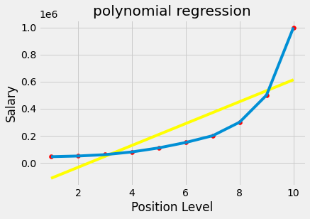

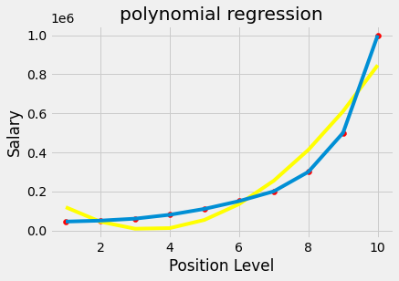

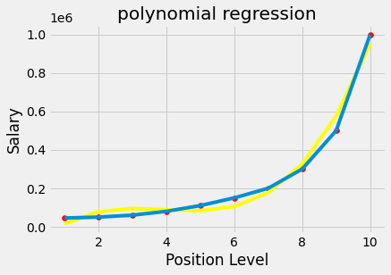

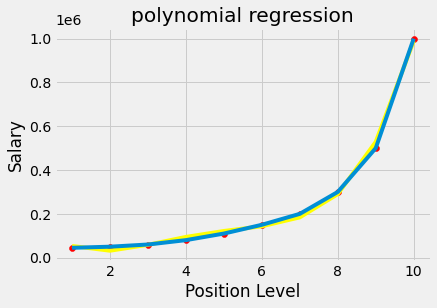

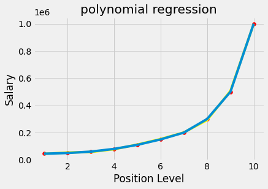

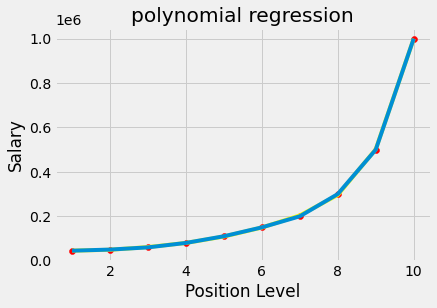

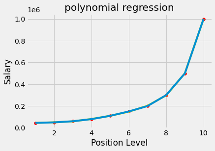

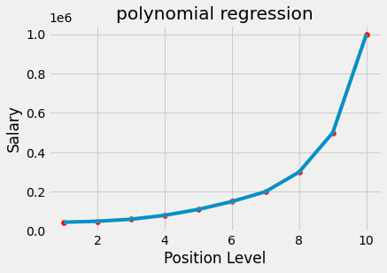

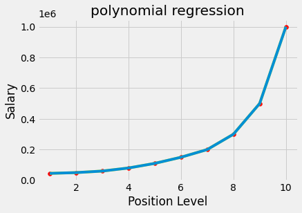

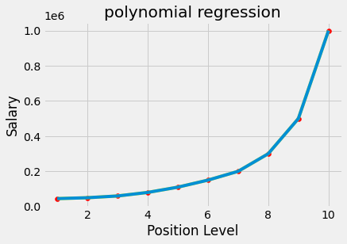

```python
# write your code here
from sklearn.metrics import mean_squared_error, r2_score
from sklearn.preprocessing import PolynomialFeatures

for i in range(1,11):
    poly=PolynomialFeatures(degree=i)
    X_poly=poly.fit_transform(X)
    lin_reg=LinearRegression()
    lin_reg.fit(X_poly,y)
    plt.scatter(X,y,color='red')
    predicted=lin_reg.predict(poly.fit_transform(X));
    plt.plot(X,predicted,color='yellow')
    plt.title('polynomial regression')
    plt.xlabel('Position Level')
    plt.ylabel('Salary')
    plt.errorbar(X, y,
              yerr = r2_score(y,lin_reg.predict(poly.fit_transform(X))))

    plt.show()
```

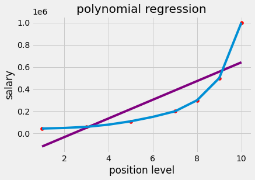

```
R2 score : 0.67
mean squared error: 26955331997.52
```

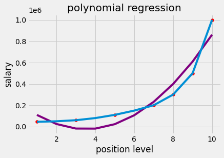

```
R2 score : 0.91
mean squared error: 7229750587.48
```

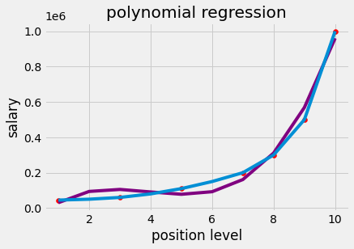

```
R2 score : 0.98
mean squared error: 1657176480.60
```

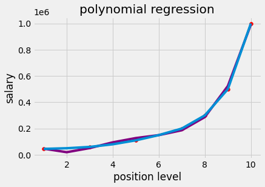

```
R2 score : 1.00
mean squared error: 247091688.96
```

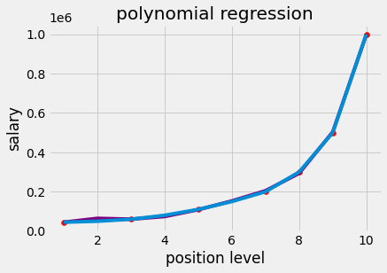

```
R2 score : 1.00
mean squared error: 34204171.21
```

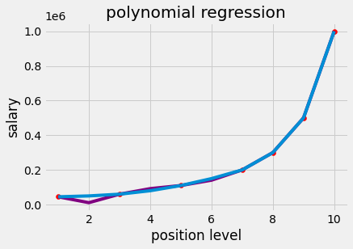

```
R2 score : 1.00
mean squared error: 174934763.61
```

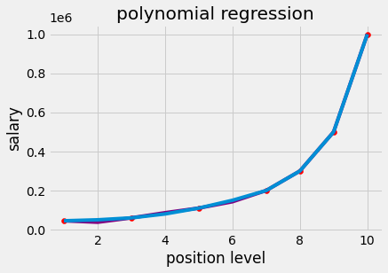

```
R2 score : 1.00
mean squared error: 24507535.48
```

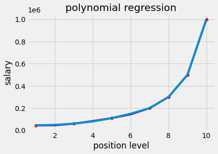

```
R2 score : 1.00
mean squared error: 6804395.28
```

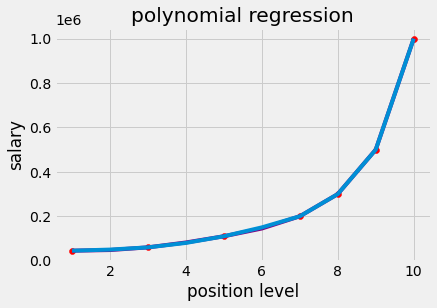

```
R2 score : 1.00
mean squared error: 3366139.52
```

```python
# write your code here
from sklearn.model_selection import train_test_split

for i in range(1,10):

    poly=PolynomialFeatures(degree=i)

    X_train,X_test,y_train,y_test = train_test_split(X, y, random_state=25,
                                  train_size=0.7)
    X_poly=poly.fit_transform(X_train)
    lin_reg=LinearRegression()
    lin_reg.fit(X_poly,y_train)
    plt.scatter(X_train,y_train,color='red')
    predicted=lin_reg.predict(poly.fit_transform(X));


    plt.plot(X,predicted,color='purple')
    plt.title('polynomial regression')
    plt.xlabel('position level')
    plt.ylabel('salary')
    plt.errorbar(X, y,
              yerr = r2_score(y,lin_reg.predict(poly.fit_transform(X))))
    plt.show()
    print("R2 score : %.2f" % r2_score(y,lin_reg.predict(poly.fit_transform(X))))
    print("mean squared error: %.2f" % mean_squared_error(y,lin_reg.predict(poly.fit_transform(X))))
```

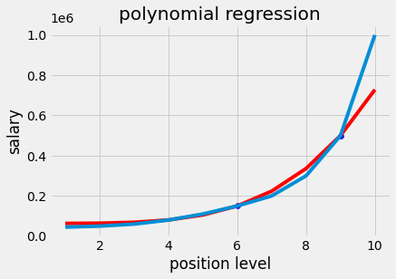

```
R2 score : 0.91
mean squared error: 7639219716.73
```

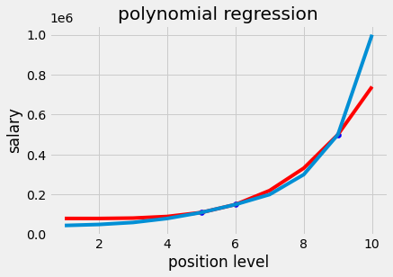

```
R2 score : 0.91
mean squared error: 7172541709.48
```

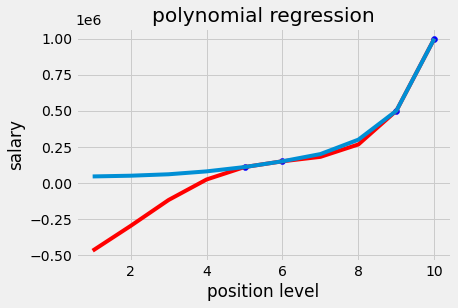

```
R2 score : 0.48
mean squared error: 42220343056.83
```

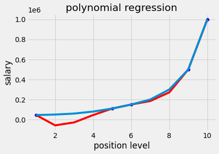

```
R2 score : 0.97
mean squared error: 2163092361.11
```

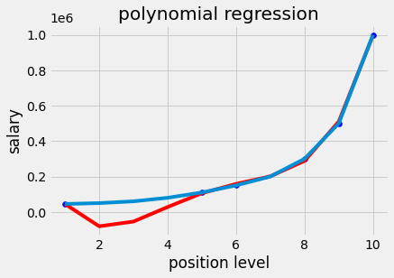

```
R2 score : 0.96
mean squared error: 3329039167.18
```

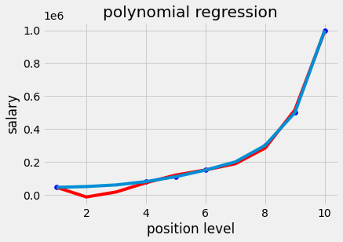

```
R2 score : 0.99
mean squared error: 671401218.95
```

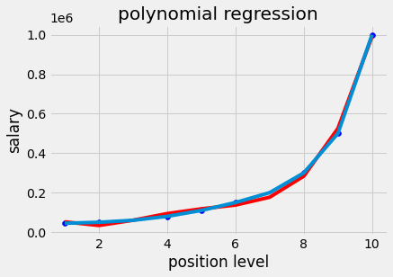

```
R2 score : 1.00
mean squared error: 227229719.60
```

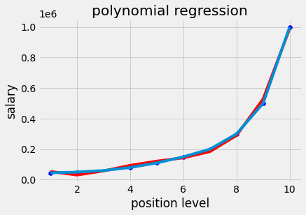

```
R2 score : 1.00
mean squared error: 210583811.93
```

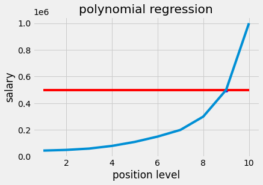

```
R2 score : -0.78
mean squared error: 143412500000.00
```

```python
# write your code here
from sklearn.model_selection import train_test_split

for j in [0.2,0.3,0.4,0.5,0.6,0.7,0.8,0.9,1]:

        poly=PolynomialFeatures(degree=4)


    # split the data with 50% in each set
        X_train,X_test,y_train,y_test = train_test_split(X, y, random_state=15,
                                  train_size=j)
        X_poly=poly.fit_transform(X_train)
        lin_reg=LinearRegression()
        lin_reg.fit(X_poly,y_train)
        plt.scatter(X_train,y_train,color='blue')
        predicted=lin_reg.predict(poly.fit_transform(X));


        plt.plot(X,predicted,color='red')
        plt.title('polynomial regression')
        plt.xlabel('position level')
        plt.ylabel('salary')
        plt.errorbar(X, y,
              yerr = r2_score(y,lin_reg.predict(poly.fit_transform(X))))
        plt.show()
        print("R2 score : %.2f" % r2_score(y,lin_reg.predict(poly.fit_transform(X))))
        print("mean squared error: %.2f" % mean_squared_error(y,lin_reg.predict(poly.fit_transform(X))))
```